```
title: "Breaking Bad Viewership Analysis"
author: "Paidamoyo Simba"
date: "2025-05-24"
output: html_document
---
```

# *Breaking Bad*

**Breaking Bad** is an American television drama series created by *Vince Gilligan*. It aired from **2008 to 2013** and starred **Bryan Cranston** as Walter White, a chemistry teacher turned methamphetamine producer, and **Aaron Paul** as his former student and business partner Jesse Pinkman.

The show received critical acclaim for its writing, acting, and cinematography, and is considered one of the greatest television series of all time.

## Logo

[figure not shown]

Breaking Bad Logo

```r
# Creating the dataset and saving it
viewership <- data.frame(
  Season = 1:5,
  Average_Viewership_Millions = c(1.23, 1.33, 1.52, 1.91, 6.04)
)

# Saving to CSV
write.csv(viewership, "data/breaking_bad_viewership.csv", row.names = FALSE)
```

```r
## Summary Statistics


library(knitr)


viewership <- read.csv("data/breaking_bad_viewership.csv")

kable(viewership, caption = "Breaking Bad Average Viewership (in Millions)")
```

Breaking Bad Average Viewership (in Millions)

| Season | Average_Viewership_Millions |
| --- | --- |
| 1 | 1.23 |
| 2 | 1.33 |
| 3 | 1.52 |
| 4 | 1.91 |
| 5 | 6.04 |

```r
# Show basic summary stats
summary(viewership$Average_Viewership_Millions)
```

```
##    Min. 1st Qu.  Median    Mean 3rd Qu.    Max.
##   1.230   1.330   1.520   2.406   1.910   6.040
```

```r
mean_viewers <- mean(viewership$Average_Viewership_Millions)
min_viewers <- min(viewership$Average_Viewership_Millions)
max_viewers <- max(viewership$Average_Viewership_Millions)

cat("Mean Viewership:", round(mean_viewers, 2), "million\n")
```

```
## Mean Viewership: 2.41 million
```

```r
cat("Minimum Viewership:", round(min_viewers, 2), "million\n")
```

```
## Minimum Viewership: 1.23 million
```

```r
cat("Maximum Viewership:", round(max_viewers, 2), "million\n")
```

```
## Maximum Viewership: 6.04 million
```

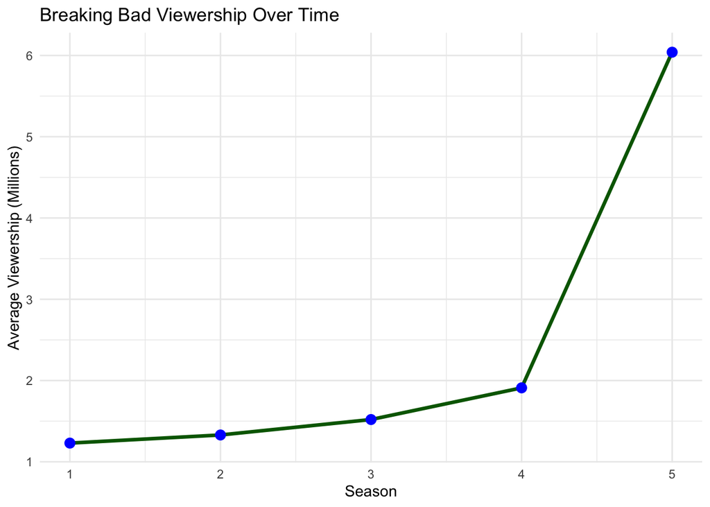

```r
## Viewership Over Time


library(ggplot2)

#  plot
ggplot(viewership, aes(x = Season, y = Average_Viewership_Millions)) +
  geom_line(color = "darkgreen", size = 1.2) +
  geom_point(color = "blue", size = 3) +
  labs(
    title = "Breaking Bad Viewership Over Time",
    x = "Season",
    y = "Average Viewership (Millions)"
  ) +
  theme_minimal()
```

```r
## The Change in Viewership from Season to Season

# Calculating change from previous season
viewership$Change_Millions <- c(NA, diff(viewership$Average_Viewership_Millions))

# Showing the data
knitr::kable(viewership, caption = "Viewership Change Between Seasons")
```

Viewership Change Between Seasons

| Season | Average_Viewership_Millions | Change_Millions |
| --- | --- | --- |
| 1 | 1.23 | NA |
| 2 | 1.33 | 0.10 |
| 3 | 1.52 | 0.19 |
| 4 | 1.91 | 0.39 |
| 5 | 6.04 | 4.13 |

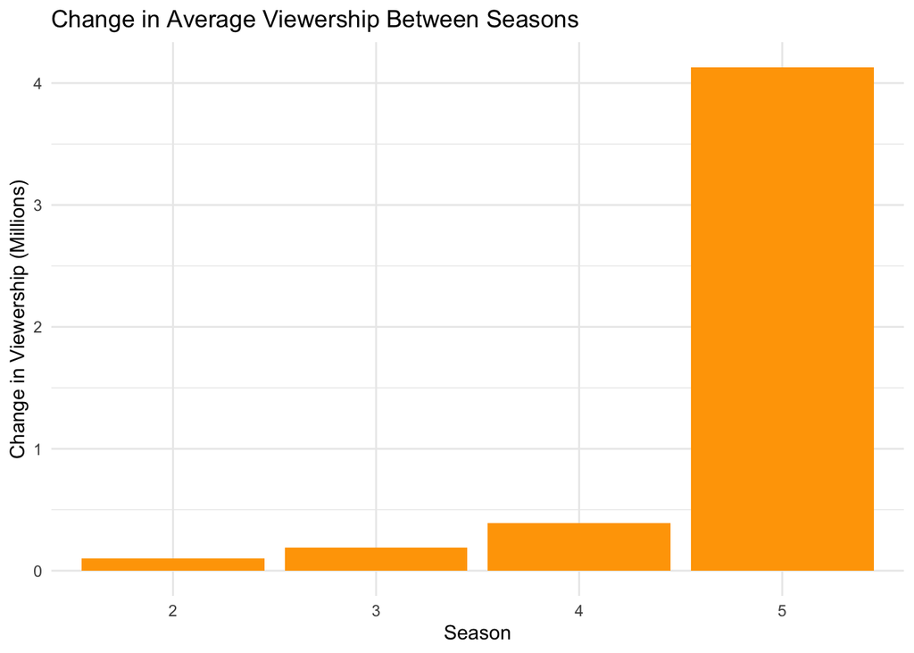

```r
# Plotting the change
ggplot(viewership[-1, ], aes(x = factor(Season), y = Change_Millions)) +
  geom_col(fill = "orange") +
  labs(
    title = "Change in Average Viewership Between Seasons",
    x = "Season",
    y = "Change in Viewership (Millions)"
  ) +
  theme_minimal()
```

## Conclusion

This short analysis of *Breaking Bad* viewership data shows a steady increase in average viewers over its five-season run. The final season saw a major spike of over 4 million additional viewers compared to Season 4, likely due to increased critical acclaim and streaming availability of earlier seasons. Visualizations and statistics highlight the show’s growing popularity and cultural impact.